# ToothGrowth Data Analysis

Pier Lorenzo Paracchini

## Overview

The goal is to analyze the ToothGrowth data in the R datasets package, performing some exploratory analysis, and then use confidence intervals and/or hypothesis tests to compare tooth growth by `supp` and `dose`.

Description of the data from the documentation *“The response is the length of odontoblasts (teeth) in each of 10 guinea pigs at each of three dose levels of Vitamin C (0.5, 1, and 2 mg) with each of two delivery methods (orange juice or ascorbic acid).”*

## Getting and Exploring the data

```r
require(datasets)
rawData <- ToothGrowth
str(rawData)
```

```
## 'data.frame':    60 obs. of  3 variables:
##  $ len : num  4.2 11.5 7.3 5.8 6.4 10 11.2 11.2 5.2 7 ...
##  $ supp: Factor w/ 2 levels "OJ","VC": 2 2 2 2 2 2 2 2 2 2 ...
##  $ dose: num  0.5 0.5 0.5 0.5 0.5 0.5 0.5 0.5 0.5 0.5 ...
```

The rawdata includes 60 obs. of 3 features. Features are `len` the tooth length (`numeric`), `supp` the supplement type (`factor`) and finally `dose`, the dose in milligrams (`numeric`). There are 6 possible groups by `supp` and `dose` (see the plot below). For each supplement `supp` (“OJ” and “VC”), there are three different groups based on the `dose` values - 0.5mg, 1mg, 2mg.

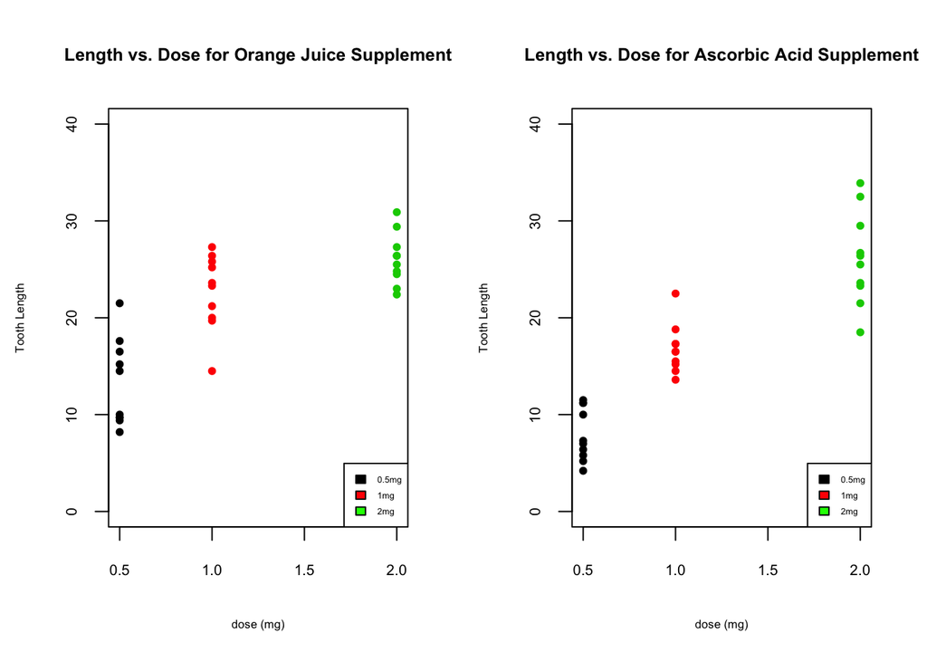

And here some basic statics about the sample tooth length for each group.

| Supp | Dose | No of Sample | Sample mean | Sample SD |
| --- | --- | --- | --- | --- |
| “OJ” | 0.5 | 10 | 13.23 | 4.46 |
| “OJ” | 1.0 | 10 | 22.7 | 3.911 |
| “OJ” | 2.0 | 10 | 26.06 | 2.655 |
| — | — | — | — | — |
| “VC” | 0.5 | 10 | 7.98 | 2.747 |
| “VC” | 1.0 | 10 | 16.77 | 2.515 |
| “VC” | 2.0 | 10 | 26.14 | 4.798 |

## Confidence Intervals & Hypothesis Testing

### Basic Assumptions

Having **each group has a limited number of sample (10 sample)** then **`t distribution` and `t confidence intervals`** are going to be used. Being the guinea pigs used for each measurement distinct from each other within a group and between the groups then the **groups can be considered independent from each other** and each guinea pig can be considered **iid**. Finally looking at the **sample standard deviation** for the different groups the assumption can be made to consider the **diffent variances as equals**.

### Independent group t confidence intervals

[output not shown]

### Hypothesis Testing

Lets perform (two sided) hypothesis testing focusing on the comparison of the 2 different supplements `OJ vs VC` and considering the following hypothesis

- **$H_0 : \mu_1 = \mu_2$**
- **$H_1 : \mu_1 \neq \mu_2$**

[output not shown]

**Interpretation**  
Remember the **p-value** represents the probability of seeing evidence as extreme or more extreme than the one obtained under $H_0$.

## Appendix

**Code used to create the basic plot to visualize basic information of the rawData.**

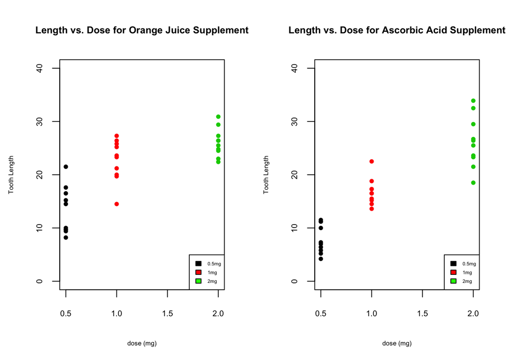

```r
require(graphics)
rawData_OJ <- rawData[rawData$supp == "OJ",]
rawData_OJ$doseF <- as.factor(rawData_OJ$dose)
rawData_VC <- rawData[rawData$supp == "VC",]
rawData_VC$doseF <- as.factor(rawData_VC$dose)

par(ps = 8, cex.lab = 0.8, mfcol = c(1,2))
plot(rawData_OJ$dose, rawData_OJ$len, col = c(rawData_OJ$doseF), pch = 20, main ="Length vs. Dose for Orange Juice Supplement", xlab = "dose (mg)", ylab ="Tooth Length", ylim=c(0, 40))
legend("bottomright",cex = 0.6, fill = c("black","red","green"), legend = c("0.5mg","1mg","2mg"))

plot(rawData_VC$dose, rawData_VC$len, col = c(rawData_VC$doseF), pch = 20, main ="Length vs. Dose for Ascorbic Acid Supplement", xlab = "dose (mg)", ylab ="Tooth Length", , ylim=c(0, 40))
legend("bottomright",cex = 0.6, fill = c("black","red","green"), legend = c("0.5mg","1mg","2mg"))
```

**Code used to prepare the data of the different groups**

```r
len_OJ <- rawData[rawData$supp == "OJ",]$len
len_OJ_05 <- rawData[rawData$supp == "OJ" & rawData$dose == 0.5,]$len
len_OJ_10 <- rawData[rawData$supp == "OJ" & rawData$dose == 1.0,]$len
len_OJ_20 <- rawData[rawData$supp == "OJ" & rawData$dose == 2.0,]$len

len_VC <- rawData[rawData$supp == "VC",]$len
len_VC_05 <- rawData[rawData$supp == "VC" & rawData$dose == 0.5,]$len
len_VC_10 <- rawData[rawData$supp == "VC" & rawData$dose == 1.0,]$len
len_VC_20 <- rawData[rawData$supp == "VC" & rawData$dose == 2.0,]$len
```

**Code used to calculate basic statistics for the different groups**

```r
getStatistics <- function(data){
  return (list(n = length(data), mean = mean(data), sd = round(sd(data),digits = 3)))
}

##OJ Statistics
stats_OJ_05 <- getStatistics(len_OJ_05)
stats_OJ_10 <- getStatistics(len_OJ_10)
stats_OJ_20 <- getStatistics(len_OJ_20)

##VC Statistics
stats_VC_05 <- getStatistics(len_VC_05)
stats_VC_10 <- getStatistics(len_VC_10)
stats_VC_20 <- getStatistics(len_VC_20)
```

**Code used to calculate t test data (confidence intervals and hypothesis testing) between the different groups**

```r
t.testOJ_10_vs_05 <- t.test(len_OJ_10, len_OJ_05, paired = FALSE, var.equal = TRUE)
t.testOJ_20_vs_05 <- t.test(len_OJ_20, len_OJ_05, paired = FALSE, var.equal = TRUE)
t.testOJ_20_vs_10 <- t.test(len_OJ_20, len_OJ_10, paired = FALSE, var.equal = TRUE)

t.testVC_10_vs_05 <- t.test(len_VC_10, len_VC_05, paired = FALSE, var.equal = TRUE)
t.testVC_20_vs_05 <-t.test(len_VC_20, len_VC_05, paired = FALSE, var.equal = TRUE)
t.testVC_20_vs_10 <-t.test(len_VC_20, len_VC_10, paired = FALSE, var.equal = TRUE)

t.testOJ_05_vs_VC_05 <- t.test(len_OJ_05, len_VC_05, paired = FALSE, var.equal = TRUE)
t.testOJ_10_vs_VC_10 <- t.test(len_OJ_10, len_VC_10, paired = FALSE, var.equal = TRUE)
t.testOJ_20_vs_VC_20 <- t.test(len_OJ_20, len_VC_20, paired = FALSE, var.equal = TRUE)

t.testOJ_vs_VC <- t.test(len_OJ, len_VC, paired = FALSE, var.equal = TRUE)
```

**Markdown used for the generation of the different tables**  
Note in the following markdown the **`** has been changed to **’** in the inline code, in order to be able to show the code itself.

Table of Sample statistics

```
Supp | Dose | No of Sample | Sample mean | Sample SD
---- | ---- | ---- | ---- | ----
"OJ" | 0.5 | 'r stats_OJ_05$n' | 'r stats_OJ_05$mean' | 'r stats_OJ_05$sd'
...
```

Table of Confidence Intervals

```
__Group1__ | __Group2__ | __t confidence interval (g1, g2)__
---- | ---- | ----
__OJ, 1.0__ | __OJ, 0.5__ | 'r t.testOJ_10_vs_05$conf' __(1)__
...
```

Table of Hypothesis Testing

```
__Group1__ | __Group2__ | __t__ | __df__ | __p-value__
---- | ---- | ---- | ---- | ----
__OJ, all__ | __VC, all__ | 'r t.testOJ_vs_VC$statistic' | 'r t.testOJ_vs_VC$parameter' | 'r t.testOJ_vs_VC$p.value'
```